# REVISED FINAL Action Seniors - CogFrailty Analyses (August 28, 2023)

```r
print("CogFrail Usual Care");apply(data1c_CogFrail_UC[c(2:14)], 2, function(x) length(which(!is.na(x)))) #count people with falls data
```

```
## [1] "CogFrail Usual Care"
```

```
##  Month_1  Month_2  Month_3  Month_4  Month_5  Month_6  Month_7  Month_8
##       98       97       95       94       93       89       89       87
##  Month_9 Month_10 Month_11 Month_12 Month_13
##       87       86       86       85       82
```

```r
print("No CogFrail Exercise");apply(data1c_NoCogFrail_EX[c(2:14)], 2, function(x) length(which(!is.na(x)))) #count people with falls data
```

```
## [1] "No CogFrail Exercise"
```

```
##  Month_1  Month_2  Month_3  Month_4  Month_5  Month_6  Month_7  Month_8
##       76       76       73       73       73       72       71       70
##  Month_9 Month_10 Month_11 Month_12 Month_13
##       70       70       68       68       67
```

```r
print("No CogFrail Usual Care");apply(data1c_NoCogFrail_UC[c(2:14)], 2, function(x) length(which(!is.na(x)))) #count people with falls data
```

```
## [1] "No CogFrail Usual Care"
```

```
##  Month_1  Month_2  Month_3  Month_4  Month_5  Month_6  Month_7  Month_8
##       70       70       69       68       67       66       65       65
##  Month_9 Month_10 Month_11 Month_12 Month_13
##       65       64       63       63       62
```

```r
data1c.stacked<-reshape(data1c,idvar="ID",varying=c(2:27),direction="long",sep="_")
data1c.stacked$time<-data1c.stacked$time-1

Fallsmeans<-data.frame(aggregate(MonthCumulative~Group*CogFrail+time,data1c.stacked,sum))
subset(Fallsmeans, CogFrail=="Yes")
```

```
##    Group CogFrail time MonthCumulative
## 3      0      Yes    0              14
## 4      1      Yes    0              10
## 7      0      Yes    1              41
## 8      1      Yes    1              24
## 11     0      Yes    2              60
## 12     1      Yes    2              41
## 15     0      Yes    3              81
## 16     1      Yes    3              49
## 19     0      Yes    4             111
## 20     1      Yes    4              61
## 23     0      Yes    5             125
## 24     1      Yes    5              70
## 27     0      Yes    6             148
## 28     1      Yes    6              77
## 31     0      Yes    7             163
## 32     1      Yes    7              91
## 35     0      Yes    8             176
## 36     1      Yes    8             102
## 39     0      Yes    9             194
## 40     1      Yes    9             114
## 43     0      Yes   10             214
## 44     1      Yes   10             124
## 47     0      Yes   11             236
## 48     1      Yes   11             132
## 51     0      Yes   12             244
## 52     1      Yes   12             136
```

Estimated differences in falls per person-year at 12 months

```r
CogFrail$falls_ppy<-CogFrail$TotalFalls/(CogFrail$TotalExposure/365)

fallsppy_lm<-lm(falls_ppy~Group,  subset(CogFrail, exclude==0))
summary(fallsppy_lm)
```

```
##
## Call:
## lm(formula = falls_ppy ~ Group, data = subset(CogFrail, exclude ==
##     0))
##
## Residuals:
##     Min      1Q  Median      3Q     Max
## -2.6359 -1.6359 -0.6359  0.4057 20.3641
##
## Coefficients:
##             Estimate Std. Error t value Pr(>|t|)
## (Intercept)   2.6359     0.3322   7.936 1.76e-13 ***
## Group        -1.0416     0.4772  -2.183   0.0303 *
## ---
## Signif. codes:  0 '***' 0.001 '**' 0.01 '*' 0.05 '.' 0.1 ' ' 1
##
## Residual standard error: 3.305 on 190 degrees of freedom
## Multiple R-squared:  0.02446,    Adjusted R-squared:  0.01932
## F-statistic: 4.763 on 1 and 190 DF,  p-value: 0.0303
```

```r
lsmeans(fallsppy_lm, ~Group)
```

```
##  Group lsmean    SE  df lower.CL upper.CL
##      0   2.64 0.332 190    1.981     3.29
##      1   1.59 0.343 190    0.918     2.27
##
## Confidence level used: 0.95
```

```r
contrast(lsmeans(fallsppy_lm, ~~Group), "trt.vs.ctrl", adj="none")
```

```
##  contrast        estimate    SE  df t.ratio p.value
##  Group1 - Group0    -1.04 0.477 190  -2.183  0.0303
```

Estimated differences in falls per person-year at 6 months

```r
CogFrail$falls_ppy_6mnths<-CogFrail$TotalFalls6Months/(CogFrail$TotalExposure/182.5)

fallsppy_6mnths_lm<-lm(falls_ppy_6mnths~Group,  subset(CogFrail, exclude==0))
summary(fallsppy_6mnths_lm)
```

```
##
## Call:
## lm(formula = falls_ppy_6mnths ~ Group, data = subset(CogFrail,
##     exclude == 0))
##
## Residuals:
##     Min      1Q  Median      3Q     Max
## -0.7025 -0.7025 -0.4160  0.2975  4.7453
##
## Coefficients:
##             Estimate Std. Error t value Pr(>|t|)
## (Intercept)  0.70247    0.09557   7.350 5.71e-12 ***
## Group       -0.28649    0.13732  -2.086   0.0383 *
## ---
## Signif. codes:  0 '***' 0.001 '**' 0.01 '*' 0.05 '.' 0.1 ' ' 1
##
## Residual standard error: 0.9509 on 190 degrees of freedom
## Multiple R-squared:  0.0224, Adjusted R-squared:  0.01725
## F-statistic: 4.353 on 1 and 190 DF,  p-value: 0.03829
```

```r
lsmeans(fallsppy_6mnths_lm, ~Group)
```

```
##  Group lsmean     SE  df lower.CL upper.CL
##      0  0.702 0.0956 190    0.514    0.891
##      1  0.416 0.0986 190    0.221    0.610
##
## Confidence level used: 0.95
```

```r
contrast(lsmeans(fallsppy_6mnths_lm, ~~Group), "trt.vs.ctrl", adj="none")
```

```
##  contrast        estimate    SE  df t.ratio p.value
##  Group1 - Group0   -0.286 0.137 190  -2.086  0.0383
```

Differences in exposure time

```r
expopsure_lm<-lm(TotalExposure~Group,  subset(CogFrail, exclude==0))
summary(expopsure_lm)
```

```
##
## Call:
## lm(formula = TotalExposure ~ Group, data = subset(CogFrail, exclude ==
##     0))
##
## Residuals:
##     Min      1Q  Median      3Q     Max
## -331.80   20.20   20.20   36.28   92.20
##
## Coefficients:
##             Estimate Std. Error t value Pr(>|t|)
## (Intercept)  344.798      8.104  42.545   <2e-16 ***
## Group        -16.078     11.645  -1.381    0.169
## ---
## Signif. codes:  0 '***' 0.001 '**' 0.01 '*' 0.05 '.' 0.1 ' ' 1
##
## Residual standard error: 80.64 on 190 degrees of freedom
## Multiple R-squared:  0.009933,   Adjusted R-squared:  0.004722
## F-statistic: 1.906 on 1 and 190 DF,  p-value: 0.169
```

```r
lsmeans(expopsure_lm, ~Group)
```

```
##  Group lsmean   SE  df lower.CL upper.CL
##      0    345 8.10 190      329      361
##      1    329 8.36 190      312      345
##
## Confidence level used: 0.95
```

```r
contrast(lsmeans(expopsure_lm, ~~Group), "trt.vs.ctrl", adj="none")
```

```
##  contrast        estimate   SE  df t.ratio p.value
##  Group1 - Group0    -16.1 11.6 190  -1.381  0.1690
```

## 7.2) Secondary outcomes (Physical Function and Cognition)

Set-up for linear mixed models

```r
CogFrail_long <- reshape(as.data.frame(CogFrail),idvar="ID",varying=26:31,direction="long",sep="_")
CogFrail_long$timefactor<-as.factor(CogFrail_long$time)
```

SPPB (START HERE)

```r
SPPB_lm<-lmer(SPPB~Group.1*timefactor + scale(Gender,scale=FALSE) + SPPBbaseline + (1|ID),  subset(CogFrail_long, exclude==0))
anova(SPPB_lm)
```

```
## Type III Analysis of Variance Table with Satterthwaite's method
##                               Sum Sq Mean Sq NumDF  DenDF  F value  Pr(>F)
## Group.1                        0.159   0.159     1 153.83   0.1528 0.69642
## timefactor                     0.925   0.925     1 141.41   0.8904 0.34699
## scale(Gender, scale = FALSE)   2.948   2.948     1 154.34   2.8390 0.09402 .
## SPPBbaseline                 105.198 105.198     1 156.07 101.3041 < 2e-16 ***
## Group.1:timefactor             1.513   1.513     1 141.45   1.4572 0.22940
## ---
## Signif. codes:  0 '***' 0.001 '**' 0.01 '*' 0.05 '.' 0.1 ' ' 1
```

```r
lsmeans(SPPB_lm, ~Group.1|timefactor)
```

```
## timefactor = 2:
##  Group.1   lsmean    SE  df lower.CL upper.CL
##  Interview   7.05 0.194 211     6.67     7.43
##  Otago       7.10 0.204 213     6.70     7.50
##
## timefactor = 3:
##  Group.1   lsmean    SE  df lower.CL upper.CL
##  Interview   7.08 0.197 219     6.69     7.47
##  Otago       6.84 0.209 224     6.43     7.25
##
## Results are averaged over the levels of: Gender
## Degrees-of-freedom method: kenward-roger
## Confidence level used: 0.95
```

```r
contrast(lsmeans(SPPB_lm, ~Group.1|timefactor), "trt.vs.ctrl", adj="none")
```

```
## timefactor = 2:
##  contrast          estimate    SE  df t.ratio p.value
##  Otago - Interview   0.0492 0.277 214   0.178  0.8592
##
## timefactor = 3:
##  contrast          estimate    SE  df t.ratio p.value
##  Otago - Interview  -0.2459 0.283 223  -0.870  0.3853
##
## Results are averaged over the levels of: Gender
## Degrees-of-freedom method: kenward-roger
```

```r
confint(contrast(lsmeans(SPPB_lm, ~Group.1|timefactor), "trt.vs.ctrl", adj="none"))
```

```
## timefactor = 2:
##  contrast          estimate    SE  df lower.CL upper.CL
##  Otago - Interview   0.0492 0.277 214   -0.496    0.595
##
## timefactor = 3:
##  contrast          estimate    SE  df lower.CL upper.CL
##  Otago - Interview  -0.2459 0.283 223   -0.803    0.311
##
## Results are averaged over the levels of: Gender
## Degrees-of-freedom method: kenward-roger
## Confidence level used: 0.95
```

```r
print("No significant effects")
```

```
## [1] "No significant effects"
```

Gait Speed

```r
GS_lm<-lmer(GaitSpeed~Group.1*timefactor + scale(Gender,scale=FALSE) + GaitSpeedbaseline + (1|ID),  subset(CogFrail_long, exclude==0))
anova(GS_lm)
```

```
## Type III Analysis of Variance Table with Satterthwaite's method
##                               Sum Sq Mean Sq NumDF  DenDF  F value  Pr(>F)
## Group.1                      0.00007 0.00007     1 149.35   0.0090 0.92460
## timefactor                   0.00317 0.00317     1 137.51   0.4199 0.51806
## scale(Gender, scale = FALSE) 0.02838 0.02838     1 149.82   3.7635 0.05426 .
## GaitSpeedbaseline            2.06864 2.06864     1 148.11 274.2928 < 2e-16 ***
## Group.1:timefactor           0.01911 0.01911     1 137.51   2.5336 0.11374
## ---
## Signif. codes:  0 '***' 0.001 '**' 0.01 '*' 0.05 '.' 0.1 ' ' 1
```

```r
lsmeans(GS_lm, ~Group.1|timefactor)
```

```
## timefactor = 2:
##  Group.1   lsmean     SE  df lower.CL upper.CL
##  Interview  0.774 0.0158 217    0.743    0.806
##  Otago      0.793 0.0166 219    0.760    0.826
##
## timefactor = 3:
##  Group.1   lsmean     SE  df lower.CL upper.CL
##  Interview  0.784 0.0160 225    0.753    0.816
##  Otago      0.770 0.0170 229    0.736    0.803
##
## Results are averaged over the levels of: Gender
## Degrees-of-freedom method: kenward-roger
## Confidence level used: 0.95
```

```r
contrast(lsmeans(GS_lm, ~Group.1|timefactor), "trt.vs.ctrl", adj="none")
```

```
## timefactor = 2:
##  contrast          estimate     SE  df t.ratio p.value
##  Otago - Interview   0.0185 0.0225 220   0.820  0.4133
##
## timefactor = 3:
##  contrast          estimate     SE  df t.ratio p.value
##  Otago - Interview  -0.0146 0.0230 230  -0.635  0.5259
##
## Results are averaged over the levels of: Gender
## Degrees-of-freedom method: kenward-roger
```

```r
confint(contrast(lsmeans(GS_lm, ~Group.1|timefactor), "trt.vs.ctrl", adj="none"))
```

```
## timefactor = 2:
##  contrast          estimate     SE  df lower.CL upper.CL
##  Otago - Interview   0.0185 0.0225 220  -0.0259   0.0629
##
## timefactor = 3:
##  contrast          estimate     SE  df lower.CL upper.CL
##  Otago - Interview  -0.0146 0.0230 230  -0.0600   0.0308
##
## Results are averaged over the levels of: Gender
## Degrees-of-freedom method: kenward-roger
## Confidence level used: 0.95
```

```r
print("No significant effects for CogFrail participants")
```

```
## [1] "No significant effects for CogFrail participants"
```

MoCA

```r
emm_options(opt.digits = FALSE)

MoCA_lm<-lmer(MoCA~Group.1*timefactor + scale(Gender,scale=FALSE) + MoCAbaseline + (1|ID),  subset(CogFrail_long, exclude==0))
anova(MoCA_lm)
```

```
## Type III Analysis of Variance Table with Satterthwaite's method
##                               Sum Sq Mean Sq NumDF  DenDF F value    Pr(>F)
## Group.1                       72.222  72.222     1 152.12  7.4933  0.006931 **
## timefactor                    59.051  59.051     1 153.94  6.1268  0.014398 *
## scale(Gender, scale = FALSE)   4.028   4.028     1 155.04  0.4180  0.518914
## MoCAbaseline                 261.594 261.594     1 162.84 27.1415 5.653e-07 ***
## Group.1:timefactor             0.620   0.620     1 153.94  0.0643  0.800129
## ---
## Signif. codes:  0 '***' 0.001 '**' 0.01 '*' 0.05 '.' 0.1 ' ' 1
```

```r
lsmeans(MoCA_lm, ~Group.1|timefactor)
```

```
## timefactor = 2:
##  Group.1     lsmean        SE     df lower.CL upper.CL
##  Interview 24.25745 0.3560419 289.17 23.55669 24.95821
##  Otago     23.14439 0.3790250 289.24 22.39840 23.89039
##
## timefactor = 3:
##  Group.1     lsmean        SE     df lower.CL upper.CL
##  Interview 23.26849 0.3631847 289.25 22.55367 23.98331
##  Otago     22.33920 0.3890191 289.33 21.57354 23.10487
##
## Results are averaged over the levels of: Gender
## Degrees-of-freedom method: kenward-roger
## Confidence level used: 0.95
```

```r
contrast(lsmeans(MoCA_lm, ~Group.1|timefactor), "trt.vs.ctrl", adj="none")
```

```
## timefactor = 2:
##  contrast            estimate        SE     df t.ratio p.value
##  Otago - Interview -1.1130551 0.5129257 289.63  -2.170  0.0308
##
## timefactor = 3:
##  contrast            estimate        SE     df t.ratio p.value
##  Otago - Interview -0.9292808 0.5276011 289.69  -1.761  0.0792
##
## Results are averaged over the levels of: Gender
## Degrees-of-freedom method: kenward-roger
```

```r
confint(contrast(lsmeans(MoCA_lm, ~Group.1|timefactor), "trt.vs.ctrl", adj="none"))
```

```
## timefactor = 2:
##  contrast            estimate        SE     df  lower.CL   upper.CL
##  Otago - Interview -1.1130551 0.5129257 289.63 -2.122589 -0.1035208
##
## timefactor = 3:
##  contrast            estimate        SE     df  lower.CL   upper.CL
##  Otago - Interview -0.9292808 0.5276011 289.69 -1.967698  0.1091367
##
## Results are averaged over the levels of: Gender
## Degrees-of-freedom method: kenward-roger
## Confidence level used: 0.95
```

```r
print("No significant differences at 12 months")
```

```
## [1] "No significant differences at 12 months"
```

# 8) Figure 2 - Accumulation of falls by treatment group for cognitively frail participants

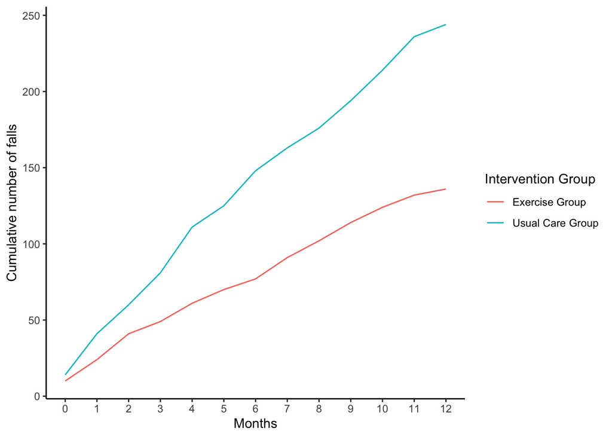

```r
Fallsmeans$GroupCogFrail<-NA
Fallsmeans$GroupCogFrail[Fallsmeans$Group==0 & Fallsmeans$CogFrail=="Yes"]<-"Usual Care Group"
Fallsmeans$GroupCogFrail[Fallsmeans$Group==1 & Fallsmeans$CogFrail=="Yes"]<-"Exercise Group"

Fallsmeans.cogfrail<-subset(Fallsmeans, CogFrail=="Yes")

Cumulativefalls.Graph<- Fallsmeans.cogfrail %>%
  ggplot() + geom_line(aes(x=time, y=MonthCumulative, color=GroupCogFrail)) +
  labs(x="Months", y="Cumulative number of falls") + labs(color="Intervention Group") +
  scale_x_continuous(breaks=seq(0,13,by=1)) + scale_y_continuous(breaks=seq(0,300,by=50))+
  theme_bw() + theme(panel.border = element_blank(), panel.grid.major = element_blank(),
                     panel.grid.minor = element_blank(), axis.line = element_line(colour = "black"))
Cumulativefalls.Graph
```

# 9) Table 3 - Primary and secondary outcomes at 12 months in exercise group based on cognitive frailty status and compliance to the intervention

## 9.1) Primary outcomes (Falls)

Falls Incident Rate Ratio at 12 months (Cognitively Frail Participants)

```r
mdl.nb<-glm.nb(TotalFalls~Compliant+scale(Gender,scale=FALSE)+offset(log(TotalExposure/365)),subset(OEP2, exclude==0))
print(summary(mdl.nb))
```

```
##
## Call:
## glm.nb(formula = TotalFalls ~ Compliant + scale(Gender, scale = FALSE) +
##     offset(log(TotalExposure/365)), data = subset(OEP2, exclude ==
##     0), init.theta = 1.175183899, link = log)
##
## Deviance Residuals:
##     Min       1Q   Median       3Q      Max
## -1.5896  -1.3396  -0.2248   0.3385   2.6011
##
## Coefficients:
##                              Estimate Std. Error z value Pr(>|z|)
## (Intercept)                  0.474427   0.194876   2.435   0.0149 *
## CompliantYes                 0.007542   0.262988   0.029   0.9771
## scale(Gender, scale = FALSE) 0.513973   0.267584   1.921   0.0548 .
## ---
## Signif. codes:  0 '***' 0.001 '**' 0.01 '*' 0.05 '.' 0.1 ' ' 1
##
## (Dispersion parameter for Negative Binomial(1.1752) family taken to be 1)
##
##     Null deviance: 97.776  on 92  degrees of freedom
## Residual deviance: 94.012  on 90  degrees of freedom
## AIC: 308.17
##
## Number of Fisher Scoring iterations: 1
##
##
##               Theta:  1.175
##           Std. Err.:  0.355
##
##  2 x log-likelihood:  -300.170
```

```r
SE<-sqrt(diag(vcovHC(mdl.nb,"HC1")))
p=2*pnorm(-abs(coef(mdl.nb)/SE))
print(cbind(coef(mdl.nb),SE,p))
```

```
##                                                 SE          p
## (Intercept)                  0.474427488 0.2109244 0.02449482
## CompliantYes                 0.007542481 0.2849836 0.97888536
## scale(Gender, scale = FALSE) 0.513972610 0.2945640 0.08100941
```

```r
est<-cbind(Estimate=coef(mdl.nb),LL=coef(mdl.nb)-1.96*SE,UL=coef(mdl.nb)+1.96*SE)
exp_group<-exp(est)
print("Use these estimates and LL and UL for the 95% CI");exp_group
```

```
## [1] "Use these estimates and LL and UL for the 95% CI"
```

```
##                              Estimate        LL       UL
## (Intercept)                  1.607094 1.0629157 2.429874
## CompliantYes                 1.007571 0.5763585 1.761403
## scale(Gender, scale = FALSE) 1.671920 0.9385935 2.978197
```

```r
print("No significant effect of compliance for CogFrail participants")
```

```
## [1] "No significant effect of compliance for CogFrail participants"
```

Falls Incident Rate Ratio at 6 months (Cognitively Frail Participants)

```r
mdl.nb<-glm.nb(TotalFalls6Months~Compliant+scale(Gender,scale=FALSE)+offset(log(TotalExposure/182.5)),subset(OEP2, exclude==0))
print(summary(mdl.nb))
```

```
##
## Call:
## glm.nb(formula = TotalFalls6Months ~ Compliant + scale(Gender,
##     scale = FALSE) + offset(log(TotalExposure/182.5)), data = subset(OEP2,
##     exclude == 0), init.theta = 2.196931618, link = log)
##
## Deviance Residuals:
##     Min       1Q   Median       3Q      Max
## -1.3228  -1.1217  -0.5276   0.2735   2.2311
##
## Coefficients:
##                              Estimate Std. Error z value Pr(>|z|)
## (Intercept)                  -0.87622    0.21016  -4.169 3.06e-05 ***
## CompliantYes                 -0.02064    0.28188  -0.073    0.942
## scale(Gender, scale = FALSE)  0.38894    0.28459   1.367    0.172
## ---
## Signif. codes:  0 '***' 0.001 '**' 0.01 '*' 0.05 '.' 0.1 ' ' 1
##
## (Dispersion parameter for Negative Binomial(2.1969) family taken to be 1)
##
##     Null deviance: 94.531  on 92  degrees of freedom
## Residual deviance: 92.669  on 90  degrees of freedom
## AIC: 223.65
##
## Number of Fisher Scoring iterations: 1
##
##
##               Theta:  2.20
##           Std. Err.:  1.51
##
##  2 x log-likelihood:  -215.647
```

```r
SE<-sqrt(diag(vcovHC(mdl.nb,"HC1")))
p=2*pnorm(-abs(coef(mdl.nb)/SE))
print(cbind(coef(mdl.nb),SE,p))
```

```
##                                                 SE            p
## (Intercept)                  -0.87621542 0.2047531 1.874179e-05
## CompliantYes                 -0.02064256 0.2763490 9.404554e-01
## scale(Gender, scale = FALSE)  0.38894227 0.2848851 1.721714e-01
```

```r
est<-cbind(Estimate=coef(mdl.nb),LL=coef(mdl.nb)-1.96*SE,UL=coef(mdl.nb)+1.96*SE)
exp_group<-exp(est)
print("Use these estimates and LL and UL for the 95% CI");exp_group
```

```
## [1] "Use these estimates and LL and UL for the 95% CI"
```

```
##                               Estimate        LL        UL
## (Intercept)                  0.4163557 0.2787245 0.6219476
## CompliantYes                 0.9795690 0.5699045 1.6837129
## scale(Gender, scale = FALSE) 1.4754194 0.8441436 2.5787819
```

```r
print("No significant effect of compliance for CogFrail participants")
```

```
## [1] "No significant effect of compliance for CogFrail participants"
```

Falls Per Person-Year at 12 months (Cognitively Frail Participants)

```r
OEP2$falls_ppy<-OEP2$TotalFalls/(OEP2$TotalExposure/365)

fallsppy_comply<-lm(falls_ppy~Compliant, OEP2)
summary(fallsppy_comply)
```

```
##
## Call:
## lm(formula = falls_ppy ~ Compliant, data = OEP2)
##
## Residuals:
##     Min      1Q  Median      3Q     Max
## -1.6383 -1.5493 -0.6383  0.4507 11.4507
##
## Coefficients:
##              Estimate Std. Error t value Pr(>|t|)
## (Intercept)   1.54933    0.33194   4.667 1.05e-05 ***
## CompliantYes  0.08896    0.46694   0.191    0.849
## ---
## Signif. codes:  0 '***' 0.001 '**' 0.01 '*' 0.05 '.' 0.1 ' ' 1
##
## Residual standard error: 2.251 on 91 degrees of freedom
## Multiple R-squared:  0.0003987,  Adjusted R-squared:  -0.01059
## F-statistic: 0.0363 on 1 and 91 DF,  p-value: 0.8493
```

```r
lsmeans(fallsppy_comply, ~Compliant)
```

```
##  Compliant   lsmean        SE df  lower.CL upper.CL
##  No        1.549334 0.3319447 91 0.8899665 2.208701
##  Yes       1.638298 0.3283944 91 0.9859827 2.290613
##
## Confidence level used: 0.95
```

```r
contrast(lsmeans(fallsppy_comply, ~~Compliant), "trt.vs.ctrl", adj="none")
```

```
##  contrast   estimate       SE df t.ratio p.value
##  Yes - No 0.08896397 0.466937 91   0.191  0.8493
```

Falls Per Person-Year at 6 months (Cognitively Frail Participants)

```r
OEP2$falls_ppy_6mnths<-OEP2$TotalFalls6Months/(OEP2$TotalExposure/182.5)

fallsppy_comply<-lm(falls_ppy_6mnths~Compliant, OEP2)
summary(fallsppy_comply)
```

```
##
## Call:
## lm(formula = falls_ppy_6mnths ~ Compliant, data = OEP2)
##
## Residuals:
##      Min       1Q   Median       3Q      Max
## -0.41710 -0.41710 -0.41489  0.08511  2.37627
##
## Coefficients:
##               Estimate Std. Error t value Pr(>|t|)
## (Intercept)   0.417101   0.090403   4.614 1.29e-05 ***
## CompliantYes -0.002207   0.127168  -0.017    0.986
## ---
## Signif. codes:  0 '***' 0.001 '**' 0.01 '*' 0.05 '.' 0.1 ' ' 1
##
## Residual standard error: 0.6131 on 91 degrees of freedom
## Multiple R-squared:  3.31e-06,   Adjusted R-squared:  -0.01099
## F-statistic: 0.0003012 on 1 and 91 DF,  p-value: 0.9862
```

```r
lsmeans(fallsppy_comply, ~Compliant)
```

```
##  Compliant    lsmean         SE df  lower.CL  upper.CL
##  No        0.4171006 0.09040345 91 0.2375253 0.5966760
##  Yes       0.4148936 0.08943654 91 0.2372389 0.5925483
##
## Confidence level used: 0.95
```

```r
contrast(lsmeans(fallsppy_comply, ~~Compliant), "trt.vs.ctrl", adj="none")
```

```
##  contrast     estimate        SE df t.ratio p.value
##  Yes - No -0.002206986 0.1271679 91  -0.017  0.9862
```

## 9.2) Secondary outcomes (physical and cognitive function)

SPPB

```r
SPPB_lm<-lmer(SPPB~Compliant*factor(time) + scale(Gender,scale=FALSE) + SPPBbaseline + (1|ID), subset(OEP4, exclude == 0))
anova(SPPB_lm)
```

```
## Type III Analysis of Variance Table with Satterthwaite's method
##                               Sum Sq Mean Sq NumDF  DenDF F value    Pr(>F)
## Compliant                     2.1605  2.1605     1 69.480  2.0237   0.15933
## factor(time)                  4.3746  4.3746     1 64.919  4.0977   0.04706 *
## scale(Gender, scale = FALSE)  0.0323  0.0323     1 70.236  0.0302   0.86250
## SPPBbaseline                 30.1124 30.1124     1 72.147 28.2060 1.157e-06 ***
## Compliant:factor(time)        5.7944  5.7944     1 64.893  5.4276   0.02294 *
## ---
## Signif. codes:  0 '***' 0.001 '**' 0.01 '*' 0.05 '.' 0.1 ' ' 1
```

```r
lsmeans(SPPB_lm, ~Compliant|factor(time))
```

```
## time = 2:
##  Compliant   lsmean        SE     df lower.CL upper.CL
##  No        7.186839 0.3158305 101.14 6.560327 7.813351
##  Yes       7.250107 0.2431126 100.77 6.767823 7.732390
##
## time = 3:
##  Compliant   lsmean        SE     df lower.CL upper.CL
##  No        6.368443 0.3241806 106.03 5.725726 7.011161
##  Yes       7.307585 0.2493929 105.70 6.813124 7.802047
##
## Results are averaged over the levels of: Gender
## Degrees-of-freedom method: kenward-roger
## Confidence level used: 0.95
```

```r
contrast(lsmeans(SPPB_lm, ~Compliant|factor(time)), "trt.vs.ctrl", adj="none")
```

```
## time = 2:
##  contrast  estimate       SE     df t.ratio p.value
##  Yes - No 0.0632678 0.394076 101.40   0.161  0.8728
##
## time = 3:
##  contrast  estimate       SE     df t.ratio p.value
##  Yes - No 0.9391420 0.404930 106.52   2.319  0.0223
##
## Results are averaged over the levels of: Gender
## Degrees-of-freedom method: kenward-roger
```

```r
confint(contrast(lsmeans(SPPB_lm, ~Compliant|factor(time)), "trt.vs.ctrl", adj="none"))
```

```
## time = 2:
##  contrast  estimate       SE     df   lower.CL  upper.CL
##  Yes - No 0.0632678 0.394076 101.40 -0.7184360 0.8449717
##
## time = 3:
##  contrast  estimate       SE     df   lower.CL  upper.CL
##  Yes - No 0.9391420 0.404930 106.52  0.1363742 1.7419098
##
## Results are averaged over the levels of: Gender
## Degrees-of-freedom method: kenward-roger
## Confidence level used: 0.95
```

```r
print("Higher compliance among CogFrail participants was associated with better SPPB score at 12 months")
```

```
## [1] "Higher compliance among CogFrail participants was associated with better SPPB score at 12 months"
```

Gait Speed

```r
GS_lm<-lmer(GaitSpeed~Compliant*factor(time) + scale(Gender,scale=FALSE) + GaitSpeedbaseline + (1|ID), subset(OEP4, exclude == 0))
anova(GS_lm)
```

```
## Type III Analysis of Variance Table with Satterthwaite's method
##                               Sum Sq Mean Sq NumDF  DenDF  F value  Pr(>F)
## Compliant                    0.00001 0.00001     1 66.542   0.0012 0.97237
## factor(time)                 0.02919 0.02919     1 62.290   4.2769 0.04279 *
## scale(Gender, scale = FALSE) 0.00998 0.00998     1 67.179   1.4627 0.23074
## GaitSpeedbaseline            0.88785 0.88785     1 67.011 130.0875 < 2e-16 ***
## Compliant:factor(time)       0.02583 0.02583     1 62.240   3.7849 0.05624 .
## ---
## Signif. codes:  0 '***' 0.001 '**' 0.01 '*' 0.05 '.' 0.1 ' ' 1
```

```r
lsmeans(GS_lm, ~Compliant|factor(time))
```

```
## time = 2:
##  Compliant    lsmean         SE     df  lower.CL  upper.CL
##  No        0.7990657 0.02390021 105.19 0.7516770 0.8464544
##  Yes       0.7707937 0.01841178 104.47 0.7342844 0.8073030
##
## time = 3:
##  Compliant    lsmean         SE     df  lower.CL  upper.CL
##  No        0.7388659 0.02456456 109.81 0.6901838 0.7875480
##  Yes       0.7689658 0.01892236 109.20 0.7314631 0.8064686
##
## Results are averaged over the levels of: Gender
## Degrees-of-freedom method: kenward-roger
## Confidence level used: 0.95
```

```r
contrast(lsmeans(GS_lm, ~Compliant|factor(time)), "trt.vs.ctrl", adj="none")
```

```
## time = 2:
##  contrast    estimate         SE     df t.ratio p.value
##  Yes - No -0.02827200 0.02984593 105.43  -0.947  0.3457
##
## time = 3:
##  contrast    estimate         SE     df t.ratio p.value
##  Yes - No  0.03009991 0.03071602 110.25   0.980  0.3293
##
## Results are averaged over the levels of: Gender
## Degrees-of-freedom method: kenward-roger
```

```r
confint(contrast(lsmeans(GS_lm, ~Compliant|factor(time)), "trt.vs.ctrl", adj="none"))
```

```
## time = 2:
##  contrast    estimate         SE     df    lower.CL   upper.CL
##  Yes - No -0.02827200 0.02984593 105.43 -0.08744814 0.03090413
##
## time = 3:
##  contrast    estimate         SE     df    lower.CL   upper.CL
##  Yes - No  0.03009991 0.03071602 110.25 -0.03077047 0.09097029
##
## Results are averaged over the levels of: Gender
## Degrees-of-freedom method: kenward-roger
## Confidence level used: 0.95
```

```r
print("No significant effects")
```

```
## [1] "No significant effects"
```

MoCA

```r
MoCA_lm<-lmer(MoCA~Compliant*factor(time) + scale(Gender,scale=FALSE) + MoCAbaseline + (1|ID), subset(OEP4, exclude==0))
anova(MoCA_lm)
```

```
## Type III Analysis of Variance Table with Satterthwaite's method
##                               Sum Sq Mean Sq NumDF  DenDF F value   Pr(>F)
## Compliant                      0.309   0.309     1 69.023  0.0277 0.868305
## factor(time)                  34.177  34.177     1 70.189  3.0675 0.084240 .
## scale(Gender, scale = FALSE)   2.489   2.489     1 70.534  0.2234 0.637890
## MoCAbaseline                 128.095 128.095     1 77.698 11.4970 0.001098 **
## Compliant:factor(time)        25.187  25.187     1 70.180  2.2606 0.137191
## ---
## Signif. codes:  0 '***' 0.001 '**' 0.01 '*' 0.05 '.' 0.1 ' ' 1
```

```r
lsmeans(MoCA_lm, ~Compliant|factor(time))
```

```
## time = 2:
##  Compliant   lsmean        SE     df lower.CL upper.CL
##  No        23.67418 0.6617956 131.44 22.36503 24.98333
##  Yes       22.68336 0.5226163 131.44 21.64953 23.71719
##
## time = 3:
##  Compliant   lsmean        SE     df lower.CL upper.CL
##  No        21.75154 0.7023698 131.58 20.36214 23.14094
##  Yes       22.53717 0.5280376 131.49 21.49262 23.58172
##
## Results are averaged over the levels of: Gender
## Degrees-of-freedom method: kenward-roger
## Confidence level used: 0.95
```

```r
contrast(lsmeans(MoCA_lm, ~Compliant|factor(time)), "trt.vs.ctrl", adj="none")
```

```
## time = 2:
##  contrast   estimate        SE     df t.ratio p.value
##  Yes - No -0.9908169 0.8345275 131.63  -1.187  0.2373
##
## time = 3:
##  contrast   estimate        SE     df t.ratio p.value
##  Yes - No  0.7856325 0.8750752 131.74   0.898  0.3709
##
## Results are averaged over the levels of: Gender
## Degrees-of-freedom method: kenward-roger
```

```r
confint(contrast(lsmeans(MoCA_lm, ~Compliant|factor(time)), "trt.vs.ctrl", adj="none"))
```

```
## time = 2:
##  contrast   estimate        SE     df   lower.CL  upper.CL
##  Yes - No -0.9908169 0.8345275 131.63 -2.6416378 0.6600041
##
## time = 3:
##  contrast   estimate        SE     df   lower.CL  upper.CL
##  Yes - No  0.7856325 0.8750752 131.74 -0.9453849 2.5166499
##
## Results are averaged over the levels of: Gender
## Degrees-of-freedom method: kenward-roger
## Confidence level used: 0.95
```

```r
print("No significant differences")
```

```
## [1] "No significant differences"
```